# Ecología de Sistemas Acuáticos:

Análisis de datos de monitoreo de alta frecuencia (HFM) con R.

# 1 Paquetes importantes y sus funciones básicas

Ya hemos dado nuestros primeros pasos en R, conocemos su entorno RStudio, hemos creado nuestros primeros objetos y aplicado un par de funciones básicas. Ahora vamos a dar un paso más allá y vamos a ver algunos de lo más paquetes que pueden ser más importantes para nosotros y sus funciones más útiles.

Para esta parte de la práctica ya debemos haber descargado los datos de la plataforma GLEON como se indicó en la sección 1.

Lo primero que nos preguntaremos, ¿Qué es un paquete? Un paquete de R es un conjunto de funciones que han sido creadas con un objetivo común, por ejemplo hacer gráficas, y que han sido agrupadas para que puedan ser cargadas en R todas juntas.

Para instalar un paquete no tenemos mas que ejecutar:

```r
install.packages("nombre_del_paquete")
```

## 1.1 Importar datos

La mayoría de los paquetes que vamos a ver durante la práctica han sido agrupados en una colección de paquetes que nos permite instalarlos y cargarlos todos juntos. Esta colección de paquetes se llama [*tidyverse*](https://www.tidyverse.org/). El primer paquete que vamos a ver es [`readr`](https://cran.r-project.org/web/packages/readr/readr.pdf). Si aún no hemos instalado `tydiverse`:

```r
install.packages("tidyverse")
```

Si ya lo tenemos instalado, solo tenemos que “llamarlo” o cargarlo. Cada vez que abrimos una sesión de R hay que cargar los paquetes que vayamos a usar durante la sesión. No es necesario volver a instalarlos pero sí hay cargarlos usando la función `library()`:

```r
#Library. Al principio de nuestro scrip creamos un apartado donde iremos cargando los paquetes nos hacen falta.
library(readr) #Si solo quisieramos cargar el paquete readr.
```

```r
#Library. Al principio de nuestro scrip creamos un apartado donde iremos cargando los paquetes nos hacen falta.
library(tidyverse) #De esta forma, todos los paquetes que agrupa tydiverse: ggplot2, readr, dplyr, etc. Yo usaría esta.
```

Vemos que al cargar `tydiverse` nos informa de qué paquetes han sido cargados y algunas funciones que tienen conflicto con otros paquetes. Una vez cargado el paquete, la primera función que vamos a necesitar es `read_csv()`. Esta función nos permite importar tablas que se han guardado en formato `.csv`. Al principio de la práctica, creamos un proyecto de R, descargamos los datos de la plataforma y los guardamos en la carpeta `Datos` de nuestro directorio. Si guardasteis vuestro espacio de trabajo al salir, tendreis un objeto llamado `dt1`. Pero si no guardasteis, tendremos que importar los datos de nuevo y, además, aprovechamos para ponerle un nombre que nos sea más evocador que `dt1`, usaremos, por ejemplo, `Crystal`:

```r
Crystal <- read_csv("Datos/Datos_Crystal.csv")
```

[output not shown]

Al importar el archivo, la función reconoce automaticamente el tipo de elementos que se guarda en cada columna. Por ejemplo, la columna sampledate es de tipo fecha, mientras que year y depth_calculated son `doubles` que vienen a ser valores númericos no enteros (double no es más que la forma en la que ese número se expresa en forma binaria usando 64 bits).

No os preocupeis por el aviso (warnings) que nos da, nos aviso de que esperaba encontrar un tipo de valor en una columna que no se corresponde con lo que ha entrado. A nosotros no nos preocupa la información que hay en esa columna.[^1]

Vamos a ver un resumen de la información que tenemos disponible en la tabla de datos.

```r
#Vistazo general
summary(Crystal)
```

```
##    sampledate                      year4          daynum       sample_time
##  Min.   :2011-04-29 17:54:00   Min.   :2011   Min.   : 82.0   Min.   :   0
##  1st Qu.:2011-10-30 02:06:45   1st Qu.:2011   1st Qu.:161.0   1st Qu.: 600
##  Median :2012-09-26 16:19:30   Median :2012   Median :208.0   Median :1203
##  Mean   :2013-01-11 09:27:48   Mean   :2012   Mean   :209.3   Mean   :1183
##  3rd Qu.:2013-11-08 16:38:15   3rd Qu.:2013   3rd Qu.:257.0   3rd Qu.:1803
##  Max.   :2014-11-04 06:42:00   Max.   :2014   Max.   :323.0   Max.   :2359
##                                                               NA's   :758072
##  depth_calculated   wtaer_temp    flag_water_temp       pH
##  Min.   : 0.000   Min.   : 0.00   Mode:logical    Min.   : 0.000
##  1st Qu.: 1.000   1st Qu.: 9.79   NA's:1049068    1st Qu.: 7.390
##  Median : 1.000   Median :16.77                   Median : 7.930
##  Mean   : 4.316   Mean   :15.76                   Mean   : 8.028
##  3rd Qu.: 7.000   3rd Qu.:21.32                   3rd Qu.: 8.660
##  Max.   :19.000   Max.   :27.41                   Max.   :12.020
##
##  flag_ph         chlorophylla   flag_chlorophylla     opt_do2
##  Mode:logical   Min.   : 0.00   Length:1049068     Min.   : 0.000
##  NA's:1049068   1st Qu.: 1.59   Class :character   1st Qu.: 8.230
##                 Median : 2.45   Mode  :character   Median : 8.810
##                 Mean   : 2.87                      Mean   : 8.737
##                 3rd Qu.: 3.57                      3rd Qu.: 9.840
##                 Max.   :10.00                      Max.   :15.690
##                 NA's   :76577
##  flag_do2       opt_dosat_raw    flag_opt_dosat_raw
##  Mode:logical   Min.   :  1.00   Mode:logical
##  NA's:1049068   1st Qu.: 90.30   NA's:1049068
##                 Median :100.50
##                 Mean   : 94.27
##                 3rd Qu.:104.60
##                 Max.   :148.50
##                 NA's   :10065
```

R nos muestra para cada columna los valores mínimos, máximos, la media, la mediana y los cuartiles 1 y 3. Además, también nos dice cuantos valores faltan (NA’s). Recordad que podéis usar la función `View()` para ver los datos directamente, también podéis hacer doble click sobre el objeto `dt1`.

## 1.2 Organizar tablas

```r
#Nos quedamos sólo con los datos del 2012
Crystal_2012 <- filter(Crystal, year4 == 2012)
rm(Crystal) #Aprovechamos para eliminar el otro objeto que no nos va a servir.
```

### 1.2.1 Ejercicios:

1. *Filtra la tabla para quedarte con los datos del 2013.*
2. *Filtra la tabla para quedarte solo con los datos que fueron tomados a un metro de profundidad.*

## 1.3 Gráficas

¡Perfecto! Ahora vamos a hacer alguna gráfica. Para ello vamos a usar otro paquete, también incluido en tidyverse, `ggplot2`. Aquí os dejo otra chuleta para usar este paquete ([pincha aquí](https://raw.githubusercontent.com/rstudio/cheatsheets/master/data-visualization-2.1.pdf)). ¿Habrá cambios en la temperatura del agua a lo largo del año? Echemos un vistazo:

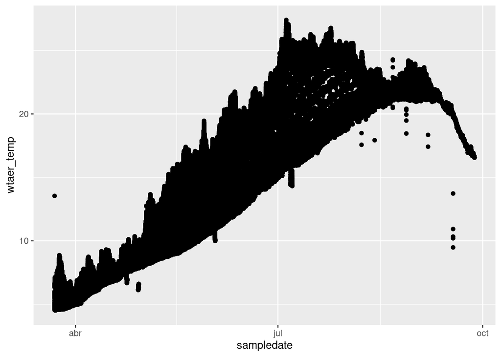

```r
ggplot(Crystal_2012, aes(x = sampledate, y= wtaer_temp))+ #Aquí indicamos donde está la información que queremos representar (Crystal_2012) y que variables x e y
  geom_point() #Aquí indicamos el tipo de gráfico, en este caso hemos elegido puntos
```

Ummm… El es un poco extraño. ¿Y si seleccionamos sólo la temperatura que tenemos a 1 metro de profundidad?

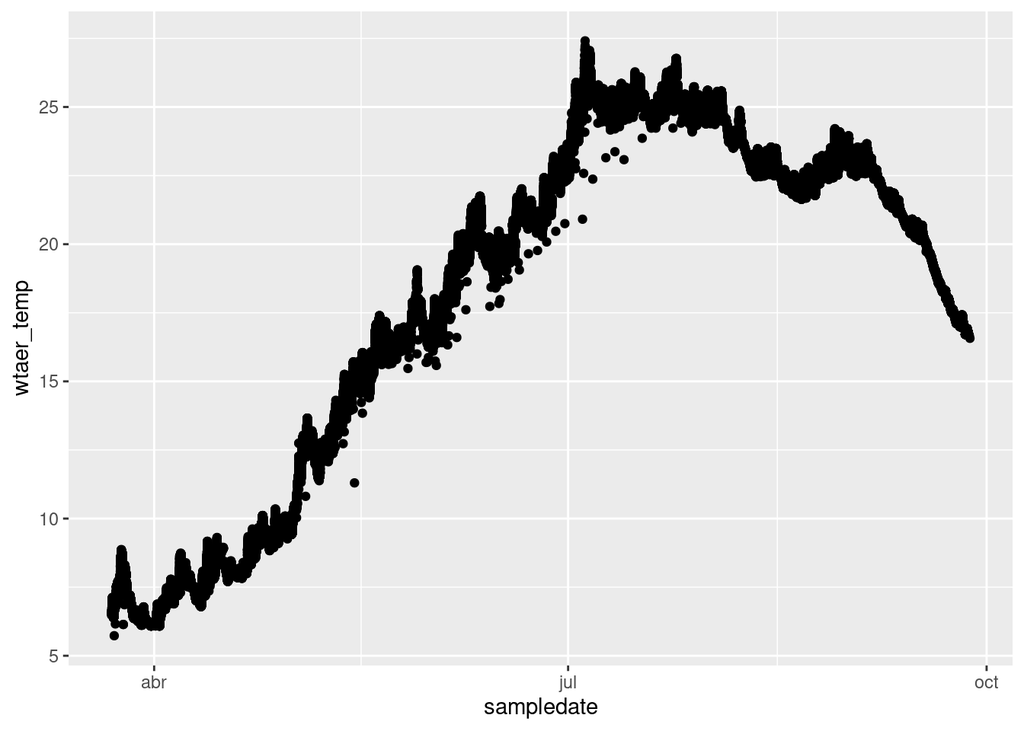

```r
Crystal_temp_1m <- filter(Crystal_2012, depth_calculated == 1)
ggplot(Crystal_temp_1m, aes(x = sampledate, y= wtaer_temp))+
  geom_point()
```

Algo mejor. Vemos que la temperatura aumenta durante la primavera y que vuelve a caer cuando se entra en el otoño. Sin embargo, a parte del patrón general, se puede observar un patrón secundario. Quizás se deba a oscilaciones diarias. Para ver eso tenemos que seleccionar la temperatura a la profundiad de 1 metros y un solo día. Con la función filter podemos hacer eso.

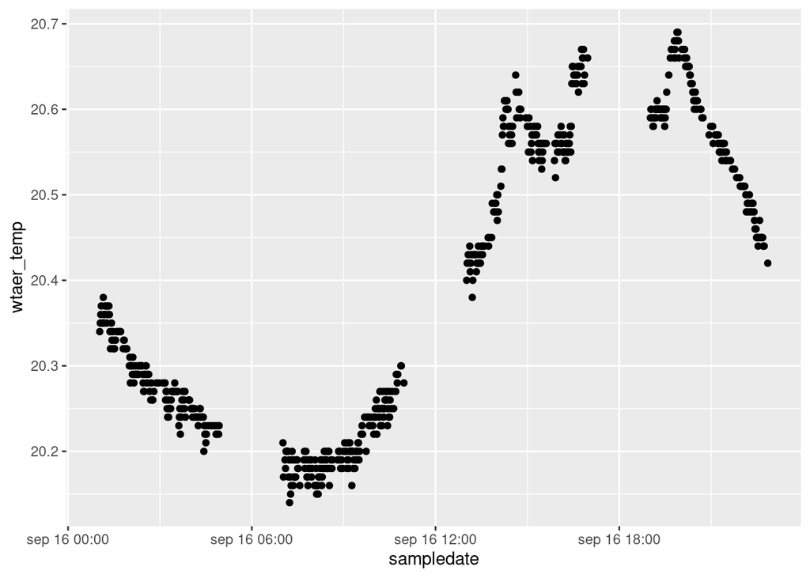

```r
Temp_1m_1dia <- filter(Crystal_2012, depth_calculated == 1 & daynum == 260) #Yo he elegido el día 260 (16 de septiembre)
ggplot(Temp_1m_1dia, aes(x=sampledate, y = wtaer_temp))+
  geom_point()
```

Parece que sí, como cabría esperar la temperatura baja por la noche y sube por el día. Además hemos aprendido una cosa nueva en R: los operadores. Os dejo los más comunes:

| Operador | Descripción |
| --- | --- |
| > | mayor que |
| < | menor que |
| >= | mayor o igual que |
| <= | menor o igual que |
| == | exactamente igual que |
| != | distinto a |
| x & y | x e y |
| x \| y | x o y |

Ahora, vamos a hacer algunos arreglos estéticos (cambiar el nombre de los ejes, el fondo)